# Identifying Fraud Rings Through Clustering

### Technical Walkthrough

**Problem:** Can transactions be grouped into clusters that concentrate fraudulent activity and may indicate coordinated behaviour?

The clustering algorithms did not use `isFraud` in their distance calculations or model fitting. Historical fraud labels were used for supervised feature selection, post-hoc cluster assessment, and validation.

**Approach:** K-Means, DBSCAN, and Hierarchical Clustering were compared using internal metrics and a holdout-oriented robustness check.

## Dataset Overview

**What was done:** Loaded and joined the raw Vesta transaction and identity tables. Profiled dataset size, fraud rate, data types, missingness, and key numeric variables before cleaning.

**Key result:** The dataset contains 590,540 transactions with a 3.50% fraud rate and substantial missing identity information.

```
Shape: (590540, 434)

Memory usage: 2513.97 MB

Fraud rate:
isFraud
Not Fraud    0.96501
Fraud        0.03499
Name: proportion, dtype: float64

Column dtypes:
float64    399
object      31
int64        4
Name: count, dtype: int64

Top 20 columns by % missing:
id_24    99.196159
id_25    99.130965
id_07    99.127070
id_08    99.127070
id_21    99.126393
id_26    99.125715
id_27    99.124699
id_23    99.124699
id_22    99.124699
dist2    93.628374
D7       93.409930
id_18    92.360721
D13      89.509263
D14      89.469469
D12      89.041047
id_04    88.768923
id_03    88.768923
D6       87.606767
id_33    87.589494
id_09    87.312290
dtype: float64

Numeric summary (key columns):
```

|  | TransactionAmt | TransactionDT |
| --- | --- | --- |
| count | 590540.000000 | 5.905400e+05 |
| mean | 135.027176 | 7.372311e+06 |
| std | 239.162522 | 4.617224e+06 |
| min | 0.251000 | 8.640000e+04 |
| 25% | 43.321000 | 3.027058e+06 |
| 50% | 68.769000 | 7.306528e+06 |
| 75% | 125.000000 | 1.124662e+07 |
| max | 31937.391000 | 1.581113e+07 |

## Cleaning and Feature Engineering

**What was done:**

- Created `has_identity_data` before dropping sparse identity fields.
- Checked for duplicate rows.
- Removed columns with more than 90% missingness.
- Created domain-derived features such as log amount, email-domain matching, frequency features, and time buckets.

Missingness was retained where it could carry fraud-related signal.

## Applied EDA: Correlation and Clustering Tendency

**What was done:** Examined feature relationships and tested clustering tendency using the Hopkins statistic across five random seeds.

**Result:** Hopkins averaged **0.974**, with a range of **0.970–0.982**.

This indicates strong non-random structure suitable for clustering. It does not, by itself, prove that the clusters represent fraud rings.

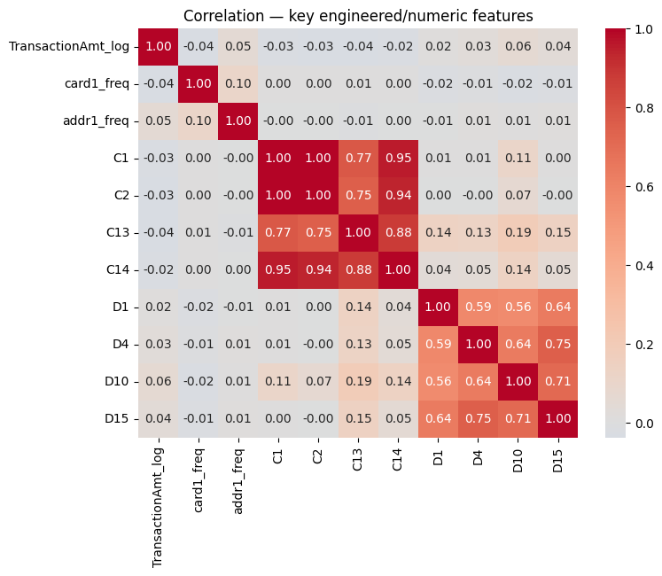

```
Hopkins statistic: 0.981  (~0.5 = random/no cluster structure, closer to 1 = clusterable)
```

```
random_state=     7  ->  Hopkins = 0.974
random_state=    21  ->  Hopkins = 0.974
random_state=   100  ->  Hopkins = 0.971
random_state=  2024  ->  Hopkins = 0.970
random_state= 55555  ->  Hopkins = 0.982

Mean: 0.974   Std Dev: 0.004
```

## Feature Selection and Dimensionality Reduction

**What was done:**

- Used Random Forest importance to identify informative variables.
- Applied variance and correlation filtering.
- Reduced the selected feature set using PCA.
- Used t-SNE on a 20,000-row sample for visual exploration.

**Result:**

- 462 engineered features reduced to 271 selected features.
- PCA retained 90% of variance using 102 components.
- t-SNE showed multiple local structures rather than one uniform data cloud.

Feature selection used historical fraud labels, so the overall pipeline is label-informed even though the clustering fit itself was unsupervised.

```
PCA: 271 features -> 102 components (90% variance retained)
```

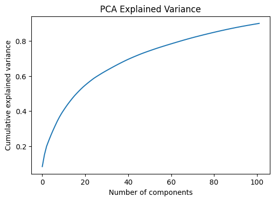

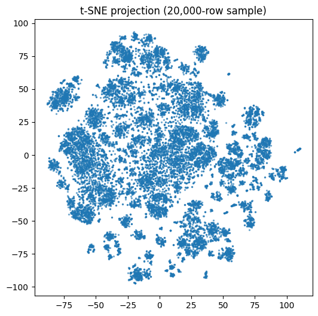

## Model Results: K-Means, DBSCAN, and Hierarchical

**What was done:** Tested three clustering approaches and assessed fraud concentration against the sample baseline.

**Configurations:**

- **K-Means:** `k=5`; 20,000-row sample
- **DBSCAN:** `eps=18.26`; `min_samples=10`; 10,000-row sample
- **Hierarchical:** Ward linkage; `k=3`; 2,000-row sample

**Result:** The notebook outputs below show the tested cluster counts, fraud rates, cluster sizes, and DBSCAN internal metrics.

Candidate settings were selected using fraud concentration after clustering, so this comparison is exploratory rather than fully label-free.

```
Baseline fraud rate in this sample: 3.57%

--- k=2 ---
         fraud_rate_%  n_transactions
cluster
0                3.58           19944
1                0.00              56

--- k=3 ---
         fraud_rate_%  n_transactions
cluster
0                2.57           17711
1               11.58            2237
2                0.00              52

--- k=4 ---
         fraud_rate_%  n_transactions
cluster
0               11.60            2233
1                2.57           17712
2                0.00              52
3                0.00               3

--- k=5 ---
         fraud_rate_%  n_transactions
cluster
0                0.00              52
1                2.47           17558
2                8.86            2223
3               54.61             152
4                6.67              15
```

```
Clusters found: 2
Noise points: 238 (2.4%)
Silhouette (excl. noise): 0.840
Davies-Bouldin (excl. noise): 0.251

Baseline fraud rate: 3.48%

         fraud_rate_%  n_transactions
cluster
-1              29.41             238
 0               2.85            9743
 1               0.00              19
```

```
Baseline fraud rate in this sample: 3.70%

--- k=2 ---
         fraud_rate_%  n_transactions
cluster
1                 3.7            1999
2                 0.0               1

--- k=3 ---
         fraud_rate_%  n_transactions
cluster
1                2.90            1793
2               10.68             206
3                0.00               1

--- k=4 ---
         fraud_rate_%  n_transactions
cluster
1                2.90            1793
2               10.45             201
3               20.00               5
4                0.00               1

--- k=5 ---
         fraud_rate_%  n_transactions
cluster
1                2.90            1793
2               10.45             201
3                0.00               3
4               50.00               2
5                0.00               1

--- k=6 ---
         fraud_rate_%  n_transactions
cluster
1                2.90            1793
2                8.38             191
3               50.00              10
4                0.00               3
5               50.00               2
6                0.00               1
```

## Model Comparison: Internal Clustering Metrics

**What was done:** Compared Silhouette, Davies-Bouldin, and Calinski-Harabasz scores across the three models.

**Interpretation:** Higher Silhouette and Calinski-Harabasz are generally better; lower Davies-Bouldin is better.

The saved notebook output is shown below.

```
K-Means (k=5):
  Silhouette: 0.336
  Davies-Bouldin: 1.662
  Calinski-Harabasz: 1298.6

DBSCAN:
  Silhouette: 0.840
  Davies-Bouldin: 0.251
  Calinski-Harabasz: 1224.2

Hierarchical (k=3):
  Silhouette: 0.392
  Davies-Bouldin: 1.435
  Calinski-Harabasz: 241.3
```

## Holdout-Oriented Validation: K-Means and DBSCAN

**What was done:** Refit K-Means and DBSCAN on 80% of their respective samples and evaluated fraud concentration on the remaining 20%.

**Interpretation:**

- K-Means declined from 15.3× exploratory concentration to approximately 3.2× on holdout data.
- DBSCAN remained concentrated at approximately 9.9× baseline on the holdout data.
- K-Means had higher recall; DBSCAN had higher precision.

**Caveat:** This is a holdout-oriented robustness check, not fully leakage-free production validation. Preprocessing was shared before splitting, and DBSCAN holdout labels were assigned using a KNN proxy.

```
Highest-risk cluster (identified on training data): 1
Training-set fraud rate in that cluster: 11.62%

Holdout baseline fraud rate: 3.57%
   fraud_rate_%  n_transactions
0          2.60            3538
1         11.49             444
2          0.00              15
3          0.00               1
4          0.00               2

--- Holdout Confusion Matrix ---
True Positives (fraud caught):    51
False Positives (false alarms):  393
True Negatives:                  3464
False Negatives (fraud missed):  92

Precision: 11.49%
Recall: 35.66%
```

```
Training fraud rate in noise (-1): 28.78%

Holdout baseline fraud rate: 3.50%
    fraud_rate_%  n_transactions
-1         34.78              23
 0          3.15            1971
 1          0.00               6

--- Holdout Confusion Matrix (DBSCAN) ---
True Positives (fraud caught):    8
False Positives (false alarms):  15
True Negatives:                  1915
False Negatives (fraud missed):  62

Precision: 34.78%
Recall: 11.43%
```

## Explainability and Proxy Fairness Audit

**What was done:**

- Compared the K-Means high-risk cluster with the remaining sample.
- Examined which product, device, card, and amount features differed.
- Audited flagging rates across the anonymous `addr1` region code.

**Important limitation:** No protected demographic attributes were available. This is therefore a proxy fairness audit, not a complete protected-group fairness assessment.

**Selected model-output findings:**

| Feature or region | High-risk / actual | Remaining / flagged |
| --- | --- | --- |
| Device data present | 98.7% | 23.5% |
| Desktop device | 76.3% | 14.2% |
| ProductCD C | 70.4% | 11.4% |
| Region 123 actual fraud | 2.97% | 0.00% flagged |
| Region 330 actual fraud | 3.49% | 0.00% flagged |

The output indicates uneven subgroup coverage and supports threshold recalibration before deployment.

```
Continuous feature comparison:
                    high_risk_cluster  rest_of_sample  ratio
TransactionAmt             114.426643      134.019226   0.85
TransactionAmt_log           4.051989        4.384484   0.92
TransactionDT_hour          12.427632       13.938432   0.89
card1_freq                   0.003269        0.004255   0.77
addr1_freq                   0.043731        0.042969   1.02

Categorical feature comparison (% of cluster in each category):
                        high_risk_%  rest_%  difference_pp
DeviceType_nan                  1.3    76.5          -75.2
ProductCD_W                     0.0    74.8          -74.8
DeviceType_desktop             76.3    14.2           62.1
ProductCD_C                    70.4    11.4           59.0
card6_credit                   48.0    25.0           23.0
card6_debit                    52.0    74.7          -22.7
amount_tier_low                45.4    24.7           20.7
ProductCD_R                    19.7     6.1           13.6
DeviceType_mobile              22.4     9.2           13.2
amount_tier_mid                14.5    25.3          -10.8
amount_tier_high               17.1    25.2           -8.1
hour_bucket_late_night         31.6    23.7            7.9
hour_bucket_evening            35.5    42.2           -6.7
hour_bucket_afternoon          23.7    29.7           -6.0
hour_bucket_morning             9.2     4.4            4.8
```

## Technical Findings and Conclusion

**Output summary:**

| Method | Exploratory result | Holdout result |
| --- | --- | --- |
| K-Means | 15.3× baseline | 3.22× baseline |
| DBSCAN | 8.45× baseline | 9.94× baseline |
| Hierarchical | 2.9× baseline | Not holdout-tested |

**Findings:**

- All three methods found fraud-concentrated groups.
- K-Means produced the highest exploratory concentration but declined substantially on holdout data.
- DBSCAN had the strongest internal metrics and remained the strongest candidate in the holdout-oriented check.
- The high-risk cluster was associated mainly with product and device-data patterns.
- The proxy fairness audit showed uneven flagging across anonymous regions.

**Recommendation:** Combine K-Means as the higher-recall candidate generator with DBSCAN as a precision-oriented filter, then recalibrate thresholds by subgroup before production deployment.